# Assignment 9

2023-11-26

## Overview

The purpose of this assignment is to examine the GradSchool_Admissions data set. first I set up the packages I’ll use and read in my data.

```r
knitr::opts_chunk$set(
    echo = TRUE,
    message = FALSE,
    warning = FALSE
)
library(tidyverse)
library(modelr)
library(easystats)
library(modelr)
library(MASS)
library(GGally)
grad <- read.csv('../../Data/GradSchool_Admissions.csv')
```

Then I take a quick look and the data I’m working with.

```r
head(grad)
```

```
##   admit gre  gpa rank
## 1     0 380 3.61    3
## 2     1 660 3.67    3
## 3     1 800 4.00    1
## 4     1 640 3.19    4
## 5     0 520 2.93    4
## 6     1 760 3.00    2
```

The data is mostly tidy but columns admit, and rank are recorded as integers. admit should be recorded as either true or false and rank would be better as a character vector.

```r
grad <- grad %>%
  mutate(admit=as.logical(admit)) %>%
  mutate(rank=as.character(rank))
head(grad)
```

```
##   admit gre  gpa rank
## 1 FALSE 380 3.61    3
## 2  TRUE 660 3.67    3
## 3  TRUE 800 4.00    1
## 4  TRUE 640 3.19    4
## 5 FALSE 520 2.93    4
## 6  TRUE 760 3.00    2
```

Now admit is a lgl vector and rank is chr vector, much better.

## Visualization

Now I can start visualizing the data to get a better idea of what to look for.

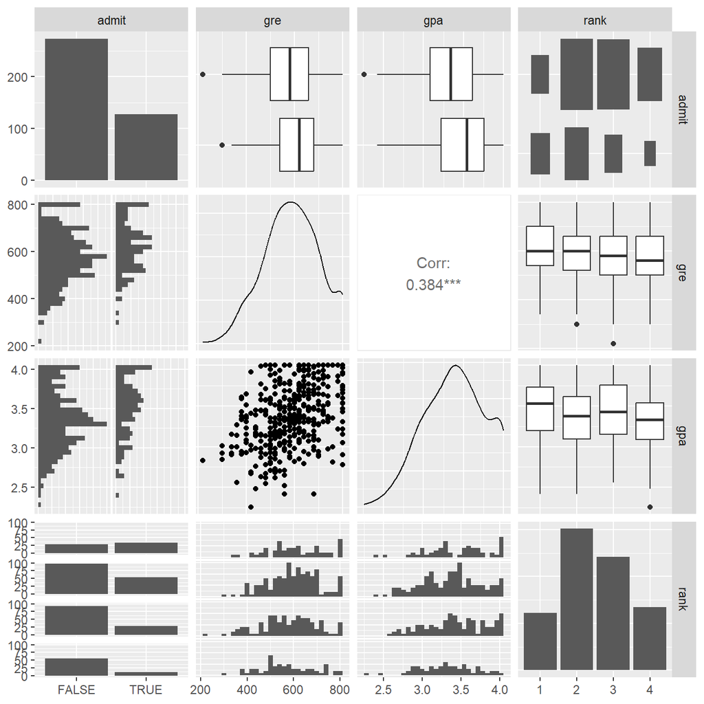

```r
ggpairs(grad)
```

Of the plots produced by ggpairs the admit vs rank in the bottom left corner stands out the most to me it looks like there might be a decent relationship between those two variables.

Here’s a closer look at the data plotted in the bottom left

```r
grad %>%
  group_by(rank) %>%
  summarise(mean(admit))
```

```
## # A tibble: 4 × 2
##   rank  `mean(admit)`
##   <chr>         <dbl>
## 1 1             0.541
## 2 2             0.358
## 3 3             0.231
## 4 4             0.179
```

It looks like the rank of the school you come from has a large impact on whether or not you’ll be accepted into grad school.

## Modeling

I started by making a fairly basic starting point model, followed by the most complex model possible. I then fed the complex model into stepAIC to find the best possible model

```r
m1<- glm(data = grad,
         formula = admit~rank+gpa+rank+gre,
         family = 'binomial')
m2 <- glm(data = grad,
          formula = admit~.^2,
          family = 'binomial')
best<- stepAIC(m2)
```

```
## Start:  AIC=480.54
## admit ~ (gre + gpa + rank)^2
##
##            Df Deviance    AIC
## - gpa:rank  3   455.25 475.25
## - gre:rank  3   455.28 475.28
## <none>          454.54 480.54
## - gre:gpa   1   457.73 481.73
##
## Step:  AIC=475.25
## admit ~ gre + gpa + rank + gre:gpa + gre:rank
##
##            Df Deviance    AIC
## - gre:rank  3   455.77 469.77
## <none>          455.25 475.25
## - gre:gpa   1   458.24 476.24
##
## Step:  AIC=469.77
## admit ~ gre + gpa + rank + gre:gpa
##
##           Df Deviance    AIC
## <none>         455.77 469.77
## - gre:gpa  1   458.52 470.52
## - rank     3   477.85 485.85
```

```r
m3 <- glm(data = grad,
            formula = best$formula,
            family = 'binomial')
```

lets test the models further

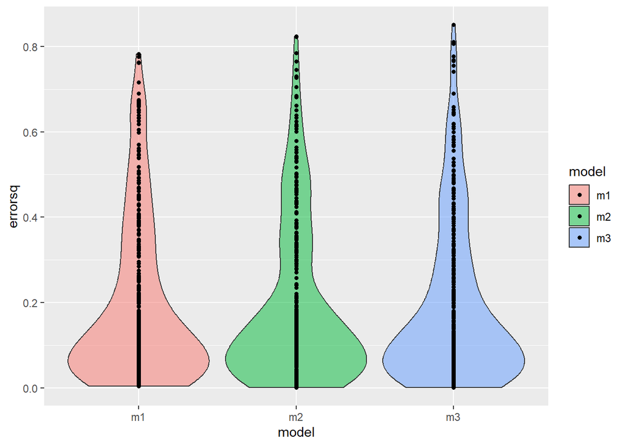

```r
error_sq <- grad %>%
mutate(m1=predict(m1, grad, "response"),
       m2=predict(m2, grad, "response"),
       m3=predict(m3, grad, "response")) %>%
pivot_longer(c(m1,m2,m3),names_to = 'model',values_to = 'errorsq') %>%
  mutate(errorsq=(admit-errorsq)^2)

error_sq %>%
  ggplot(aes(x=model,y=errorsq,fill=model))+
  geom_violin(alpha=.5)+
  geom_point2()
```

```r
error_sq %>%
  group_by(model) %>%
  summarise(mean(errorsq))
```

```
## # A tibble: 3 × 2
##   model `mean(errorsq)`
##   <chr>           <dbl>
## 1 m1              0.195
## 2 m2              0.193
## 3 m3              0.193
```

All three models seem to have pretty similar levels of error

Here is the equation for that model

```r
m3$formula
```

```
## admit ~ gre + gpa + rank + gre:gpa
```

The formula isn’t far off from my initial model

## Predictions

first I add the predictions to the grad data set

```r
grad <- grad %>%
mutate(pred=predict(m3, grad, "response"))
```

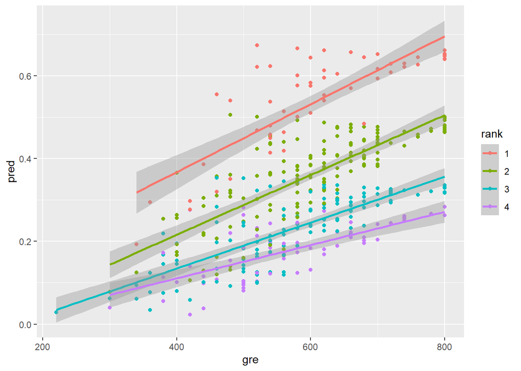

```r
grad %>%
  ggplot(aes(x=gre,y=pred,color=rank))+
  geom_point()+
  geom_smooth(method = 'lm')
```

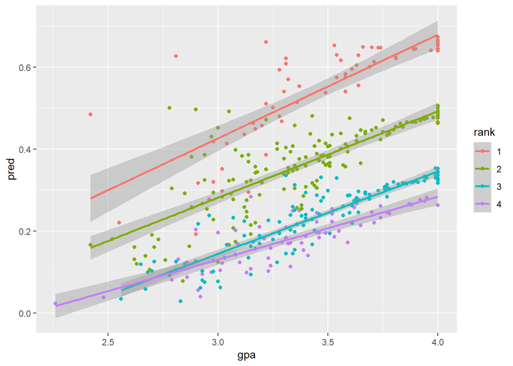

```r
grad %>%
  ggplot(aes(x=gpa,y=pred,color=rank))+
  geom_point()+
  geom_smooth(method = 'lm')
```

As predicted by ggpairs it seems like the main factor driving admittance rate is the rank of school that the student comes from, though GRE score and GPA do still impact a students chances of being accepted.